# Part II - Investigating the factors affecting the duration of biking in the busiest biking hours

## by Buhari Shehu

## Investigation Overview

> In this project, I analyse the bike sharing dataset of San Fransisco Bay Area for the first quarter of 2019. I investigated the factors that may affect the duration taken by a biker in each biking cycle. In my investigation I noted the following: -the 8th and the 17th hours are the busiest hours which indicated that a vast majority of the bikers are most likely 9-5 workers. Most of the bikings happened during the day time as expected. -the hour of the day or the gender of the bikers do not determine how long a ride will take. -most of the bikers above 60 are less likely to bike for a long duration and the few that do are mostly in the subscriber category.

## Dataset Overview

> The bike sharing dataset of San Francisco Bay Area for the first quarter of 2019 was analysed in this project. It consists of the following 16 features of diffrent data types: **`duration_sec, start_time, end_time, start_station_id, start_station_name, start_station_latitude, start_station_longitude, end_station_id, end_station_name, end_station_latitude, end_station_longitude, bike_id, user_type, member_birth_year, member_gender and bike_share_for_all_trip`.`**

## Visualization 1

In this visualization, I investigated the busiest hours in the dataset. I observe that most of the bikers are, most likely, 9-5 workers as the 8th and the 17th hours are the busiest. Majority of the rides happened during the daytimes as expected.

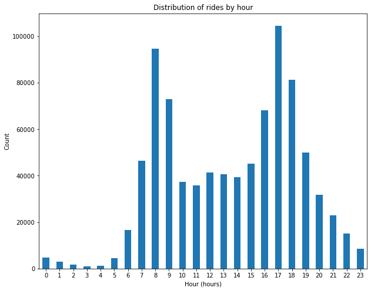

## Visualization 2

> In this plot I investigated the dataset to see how member gender and hour of the day affect biking duration. We can observe the following:
> - most of the rides happened during the day time
> - there almost equal proportions of different genders in each hour of the day that share bikes
> - a good number of those who took rides between 3:00 PM to 2:00 AM ended up spending close to one day before checking in.
> - rides between 3:00 AM and 6:00 AM rarely pass exceed 15-hour duration
> - most of the rides by the other gender lasted less than an hour.

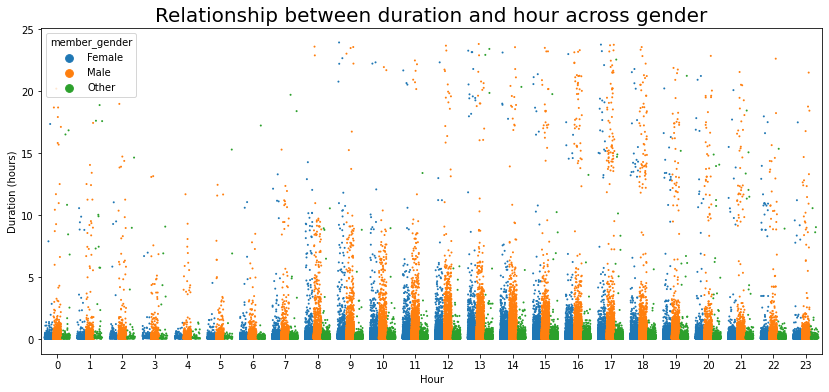

## Visualization 3

In this visualization, I check to see wether cutomer age and type affect the biking duration. I observe that

- riders above 60 years of age and tenagers are less likely to ride a bike for longer durations.
- most of those that take longer durations are in the age range of 20-40
- the user type is not a determinant of biking duration

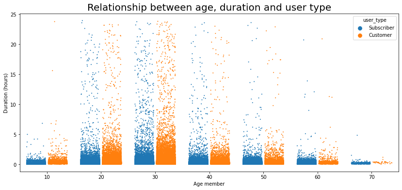